# Using multicrispr for gRNA design

Aditya M Bhagwat

2020-04-23

# 1 Background

## 1.1 Crispr/Cas9 and Prime Editing

**Crispr/Cas9** is a prokaryotic immune system turned into a genome engineering tool, with a Cas9/gRNA complex at the heart of its functioning. The **gRNA** (guide RNA) contains a 20 nucleotide (proto)**spacer** which guides the complex to a genomic locus with identical sequence, but only when followed by an *NGG* **PAM** (protospacer adjacent motif (see Figure 1A). The **Cas9** enzyme performs some effector action at that locus: *wildtype Cas9* cuts both strands after spacer nucleotide 17, *Cas9Nickase* cuts only a single strand (two variants exist, cutting respectively each of the strands), while catalytically dead *dCas9*, fused to some effector domain (KRAB, VPR, APEX) performs some alternative action (e.g. KRAB represses, VPR activates, APEX biotinylates).

**Prime Editing** extends this further, by coupling Cas9 to a Reverse Transcriptase (RT). As shown in Figure 1, the guide RNA is extended with a 3’ extension that contains primer binding site (binding a complementary DNA region that acts as a primer for reverse transcription) and reverse transcription template (the template used for reverse transcription). The spacer still acts as targeting agent, guiding the Cas9/RT complex to targeted genomic locus.

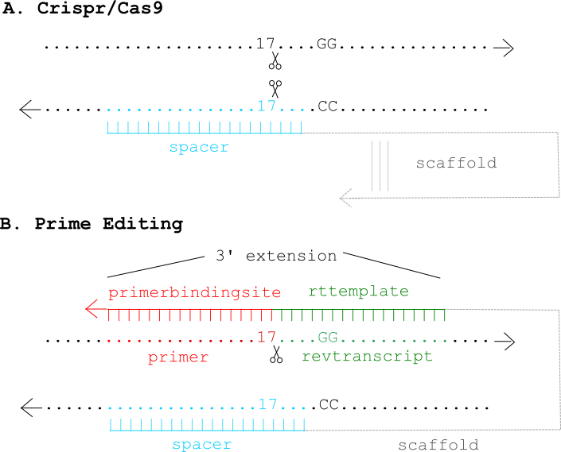

Figure 1: gRNAs for Crispr/Cas9 (A) and Prime Editing

## 1.2 Guide RNA design

**Guide RNA design** involves finding good guide RNAs to hit the targets of interest. Plasmids with guide RNA scaffolds, ready for cloning desired spacers into, can be readily ordered from AddGene. The actual task, therefore, boils down to finding good spacers for the targets of interest. For prime editing, it additionally involves finding appropriate primer binding site and reverse transcription template to edit the target site of interest.

A **good spacer** needs to fulfill two requirements.

1. **Minimal off-target** (mis)matches, so that only intended targets are hit.
   - Crispr gRNAs can hit exact (with identical and alternate NGG pam), as well as (up-to 2) mismatch offtargets.
   - Prime Editing is much more specific, hitting only exact offtargets.
2. **Maximal on-target** efficiency. Over the years, several sequence-to-efficiency prediction models have been developed, of which the Doench 2016 score has currently become the community standard. The score is not perfect, and examples can be found where the prediction and the actual outcome differ. Yet, to-date it is the best heuristic to predict on-target efficiency, worth making use of.

# 2 Multicrispr

Multicrispr was developed to make guide RNA design easier. As shown below, it contains functions to **define** and **transform** targets, **find spacers**, compute/add **offtarget counts** and **efficiency scores** (Doench 2016), and finally return all of this as a **GRanges** object.

[figure not shown]

## 2.1 Install

Installing **multicrispr** is simple:

```r
url <- 'https://gitlab.gwdg.de/loosolab/software/multicrispr.git'
remotes::install_git(url, repos = BiocManager::repositories())
```

Doench et al. (2016) ’s python package **azimuth** for on-target efficiency prediction using their method can be easily installed and activated using reticulate:

```r
# Install - run R(Studio) with admin privileges for this to work!
  reticulate::conda_create('azienv', 'python=2.7')
  reticulate::conda_install('azienv', 'azimuth', pip = TRUE)
  reticulate::conda_install('azienv', 'scikit-learn==0.17.1', pip = TRUE)
```

```r
# Activate
  reticulate::use_condaenv('azienv')
```

Bowtie-indexed genomes for quick offtarget analysis can be installed using `index_genome`. For the two genomes used in the examples, mm10 and hg38, the functions downloads pre-build indexes from our data server, allowing a quick exploration (set `download=FALSE` to build index anew):

```r
index_genome(BSgenome.Mmusculus.UCSC.mm10::BSgenome.Mmusculus.UCSC.mm10)
index_genome(BSgenome.Hsapiens.UCSC.hg38::BSgenome.Hsapiens.UCSC.hg38  )
```

## 2.2 Define targets

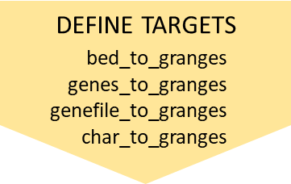

`bed_to_granges` converts a (0-based) BED coordinate file into a (1-based) GRanges.  
An example is loading the 1974 binding sites of the transcription factor SRF:

```r
require(magrittr)
require(multicrispr)
bedfile <- system.file('extdata/SRF.bed', package = 'multicrispr')
tfbs0 <- bed_to_granges(bedfile, genome = 'mm10')
```

```
##  Read SRF.bed into GRanges
##      1974 ranges on 21 chromosomes
```

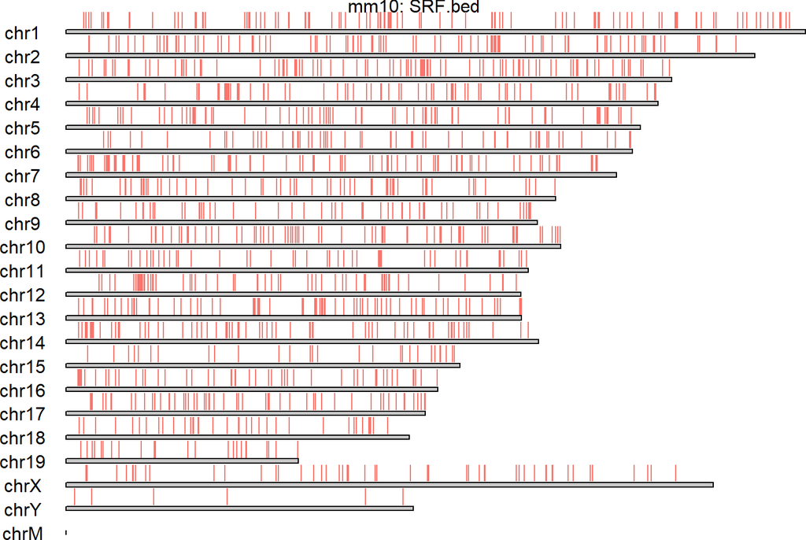

`genes_to_granges` and `genefile_to_granges` convert entrez/ensembl gene identifiers into GRanges using `txdb` gene models. An example that loads of a small subset of the 1974 SRF binding sites:

```r
require(multicrispr)
entrezfile <- system.file('extdata/SRF.entrez', package = 'multicrispr')
txdb <- TxDb.Mmusculus.UCSC.mm10.knownGene::TxDb.Mmusculus.UCSC.mm10.knownGene
sometfbs0 <- genefile_to_granges(entrezfile, txdb, complement = TRUE)
```

```
##      Convert 10 genes to 10 GRanges
##      20 ranges after adding inverse strands
```

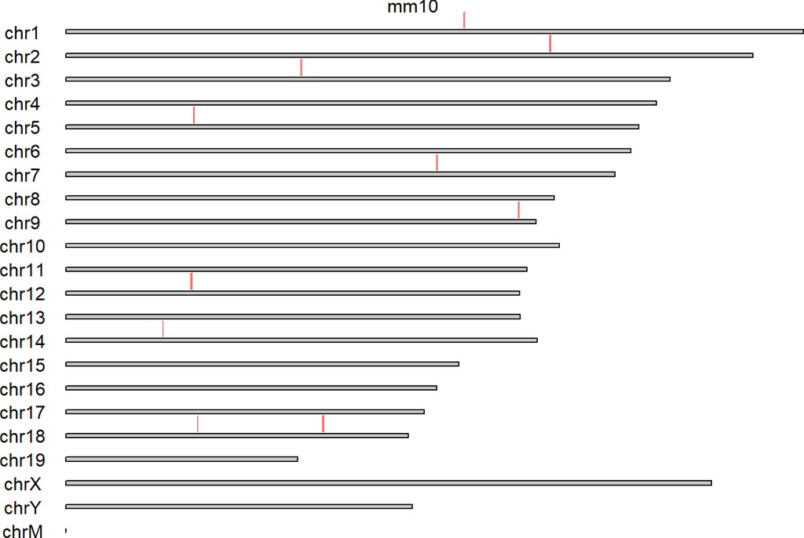

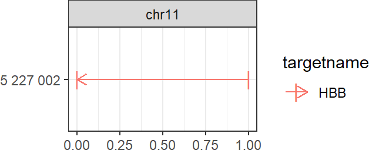

```r
# char_to_granges: Anzalone et al. (2019) prime editing targets
bsgenome <- BSgenome.Hsapiens.UCSC.hg38::BSgenome.Hsapiens.UCSC.hg38
pe0 <- char_to_granges(c(HBB  = 'chr11:5227002:-'), bsgenome)
plot_intervals(pe0)
```

## 2.3 Transform targets

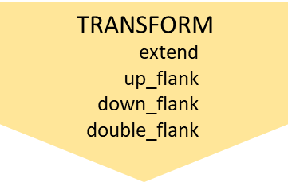

As a second step, the original targets may require transformation. The functions `extend`, `up_flank` (upstream flanks), `down_flank` (downstream flanks), and `double_flank` (double flanks) can be used to update the target ranges as required.

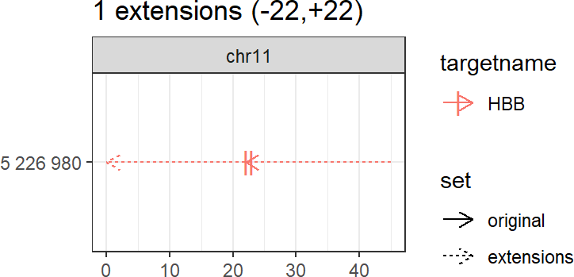

```r
# Extend
targets <- pe0
invisible(extend(targets, -22, 22, plot = TRUE))
```

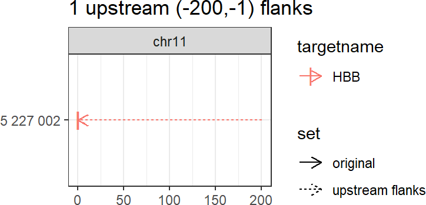

```r
# Up flank
invisible(up_flank(  targets, -200, -1, plot = TRUE))
```

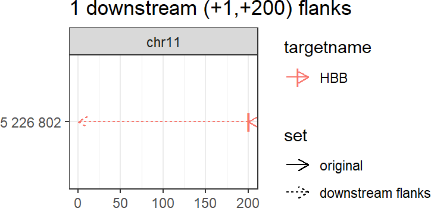

```r
# Down flank
invisible(down_flank( targets, 1, 200, plot = TRUE))
```

```
##      2 flank ranges: 1 up + 1 down
```

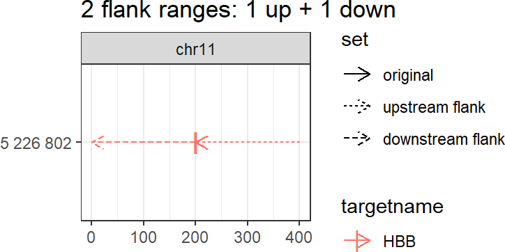

```r
# Double flank
invisible(double_flank(targets, -200, -1, +1, +200, plot = TRUE))
```

## 2.4 Find spacers

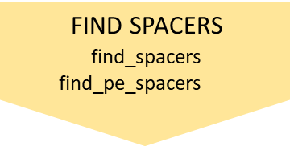

The next step is to find N20 spacers followed by NGG pam sites. This can be done with `find_spacers`, after extending target range(s) to prime editing neighbourhood(s):

```r
bsgenome   <- BSgenome.Hsapiens.UCSC.hg38::BSgenome.Hsapiens.UCSC.hg38
neighbourhood <- extend_for_pe(targets, bsgenome)
spacers    <- find_spacers(neighbourhood, bsgenome, complement = FALSE)
```

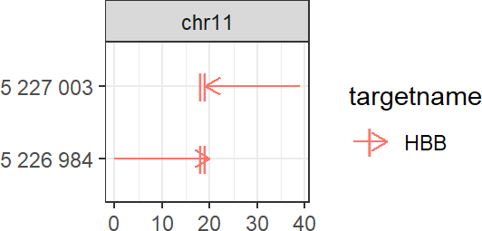

For prime editing, however, it is better to use `find_pe_spacers`, which performs target to neighbourhood extension implicitly, and also adds 3’ extension (Fig 1) to returned spacer GRanges.

```r
spacers <- find_pe_spacers(targets, bsgenome=bsgenome)
```

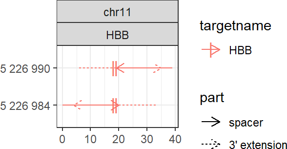

This finds prime editing sites that follow Anzalone et al. (2019)’s recommended default settings: a 13-nucleotide primer and a 16-nucleotide reverse transcription template. These settings can be easily altered (e.g. Anzalone et al. report success with reverse transcription templates of up to 48 nucleotides) by:

```r
spacers <- find_pe_spacers(targets, bsgenome=bsgenome, nrt = 48)
```

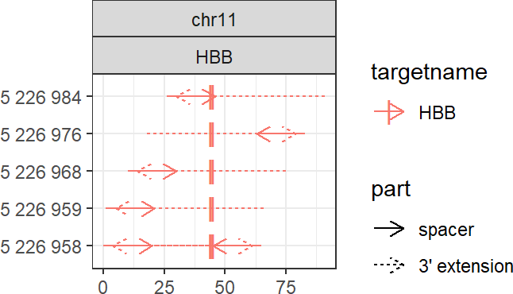

## 2.5 Add offtargets

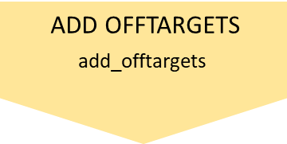

```
##  Add genome counts
##      Expand iupac ambiguities in pam
##      Write reads to ~/multicrisprout/spacers.fa
##      Map reads: ~/multicrisprout/spacers/spacers_to_BSgenome.Hsapiens.UCSC.hg38.txt
##      Load results
##      Count matches
##  Calculate offtargets for 6 spacers
```

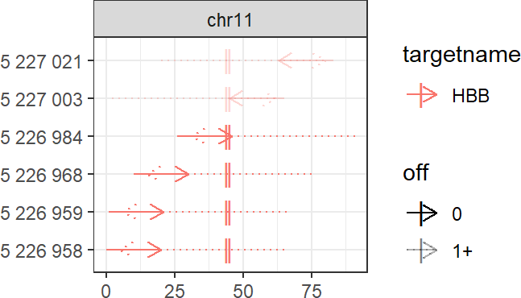

```r
if (has_been_indexed(bsgenome)){
  spacers %<>% add_offtargets(bsgenome, mismatch = 0, plot = TRUE)
}
```

## 2.6 Add efficiency

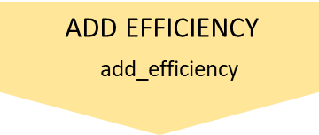

Not all N<sub>20</sub>NGG gRNA sequences target equally well (even when matching sequence perfectly). For each position in the 23-bp gRNA sequence, the nucleotide present in current, previous and next position has an effect on targeting efficiency. The current community standard for on-target efficiency prediction is that of Doench et al. (2016), which can be computed and added with `add_efficiency`:

```r
if (reticulate::py_module_available('azimuth')){
  spacers %<>% add_efficiency(bsgenome, 'Doench2016')
}
```

```
##  Score crispr spacers
##      Add (4-23-3) contextseqs
##      Score contextseqs with Doench2016 (azimuth)
##      Run Doench2016 1 times on 10000-seq chunks to preserve memory
## No model file specified, using V3_model_nopos
##      Completed in 1.2 secs
```

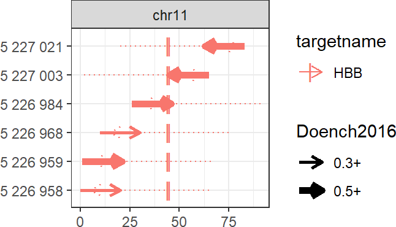

## 2.7 Return spacer GRanges

```r
  spacers
## GRanges object with 6 ranges and 14 metadata columns:
##         seqnames          ranges strand |                  crisprcontext
##            <Rle>       <IRanges>  <Rle> |                    <character>
##   HBB_1    chr11 5226958-5226977      + | TCATCCACGTTCACCTTGCCCCACAGGGCA
##   HBB_2    chr11 5226959-5226978      + | CATCCACGTTCACCTTGCCCCACAGGGCAG
##   HBB_3    chr11 5226968-5226987      + | TCACCTTGCCCCACAGGGCAGTAACGGCAG
##   HBB_4    chr11 5227003-5227022      - | ACACCATGGTGCATCTGACTCCTGAGGAGA
##   HBB_5    chr11 5226984-5227003      + | GGCAGTAACGGCAGACTTCTCCTCAGGAGT
##   HBB_6    chr11 5227021-5227040      - | ACTAGCAACCTCAAACAGACACCATGGTGC
##          targetname targetstart targetend  crisprname         crisprspacer
##         <character>   <integer> <integer> <character>          <character>
##   HBB_1         HBB     5227002   5227002       HBB_1 CCACGTTCACCTTGCCCCAC
##   HBB_2         HBB     5227002   5227002       HBB_2 CACGTTCACCTTGCCCCACA
##   HBB_3         HBB     5227002   5227002       HBB_3 CTTGCCCCACAGGGCAGTAA
##   HBB_4         HBB     5227002   5227002       HBB_4 CATGGTGCATCTGACTCCTG
##   HBB_5         HBB     5227002   5227002       HBB_5 GTAACGGCAGACTTCTCCTC
##   HBB_6         HBB     5227002   5227002       HBB_6 GCAACCTCAAACAGACACCA
##           crisprpam        primer
##         <character>   <character>
##   HBB_1         AGG GTTCACCTTGCCC
##   HBB_2         GGG TTCACCTTGCCCC
##   HBB_3         CGG CCCCACAGGGCAG
##   HBB_4         AGG GTGCATCTGACTC
##   HBB_5         AGG CGGCAGACTTCTC
##   HBB_6         TGG CCTCAAACAGACA
##                                            revtranscript
##                                              <character>
##   HBB_1 CACAGGGCAGTAACGGCAGACTTCTCCTCAGGAGTCAGATGCACCATG
##   HBB_2 ACAGGGCAGTAACGGCAGACTTCTCCTCAGGAGTCAGATGCACCATGG
##   HBB_3 TAACGGCAGACTTCTCCTCAGGAGTCAGATGCACCATGGTGTCTGTTT
##   HBB_4 CTGAGGAGAAGTCTGCCGTTACTGCCCTGTGGGGCAAGGTGAACGTGG
##   HBB_5 CTCAGGAGTCAGATGCACCATGGTGTCTGTTTGAGGTTGCTAGTGAAC
##   HBB_6 CCATGGTGCATCTGACTCCTGAGGAGAAGTCTGCCGTTACTGCCCTGT
##                                                             extension        G0
##                                                           <character> <integer>
##   HBB_1 CATGGTGCATCTGACTCCTGAGGAGAAGTCTGCCGTTACTGCCCTGTGGGGCAAGGTGAAC         1
##   HBB_2 CCATGGTGCATCTGACTCCTGAGGAGAAGTCTGCCGTTACTGCCCTGTGGGGCAAGGTGAA         1
##   HBB_3 AAACAGACACCATGGTGCATCTGACTCCTGAGGAGAAGTCTGCCGTTACTGCCCTGTGGGG         1
##   HBB_4 CCACGTTCACCTTGCCCCACAGGGCAGTAACGGCAGACTTCTCCTCAGGAGTCAGATGCAC         2
##   HBB_5 GTTCACTAGCAACCTCAAACAGACACCATGGTGCATCTGACTCCTGAGGAGAAGTCTGCCG         1
##   HBB_6 ACAGGGCAGTAACGGCAGACTTCTCCTCAGGAGTCAGATGCACCATGGTGTCTGTTTGAGG         2
##               off      off0        Doench2016
##         <numeric> <numeric>         <numeric>
##   HBB_1         0         0 0.462600534483403
##   HBB_2         0         0 0.611140169152868
##   HBB_3         0         0 0.485226524206282
##   HBB_4         1         1 0.666241339730174
##   HBB_5         0         0 0.517610901468318
##   HBB_6         1         1  0.68921726226521
##   -------
##   seqinfo: 455 sequences (1 circular) from hg38 genome
```